# Lab 3 - Probability & Simulations

202330420212-Sihan Chen & 202364820921-Yue Zhang

2025-04-09

# 1 Introduction

# 2 Exercise 1 - Simulating a Coin Flip

We simulate flipping a fair coin 1000 times.

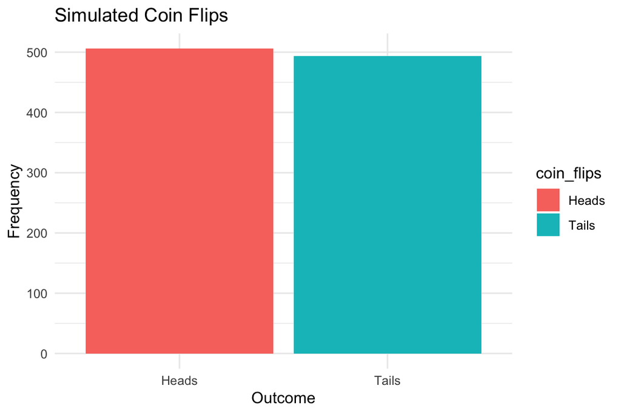

```r
set.seed(123)
coin_flips <- sample(c("Heads", "Tails"), size = 1000, replace = TRUE)

# Convert to table and data frame
flip_table <- table(coin_flips)
flip_df <- as.data.frame(flip_table)

# Bar plot
ggplot(flip_df, aes(x = coin_flips, y = Freq, fill = coin_flips)) +
  geom_bar(stat = "identity") +
  labs(title = "Simulated Coin Flips", x = "Outcome", y = "Frequency") +
  theme_minimal()
```

Observation: The outcomes of Heads and Tails are nearly balanced, reflecting a fair coin simulation.

# 3 Exercise 2 - Simulating Dice Rolls

Simulate rolling a fair six-sided die 1000 times and compare with uniform distribution.

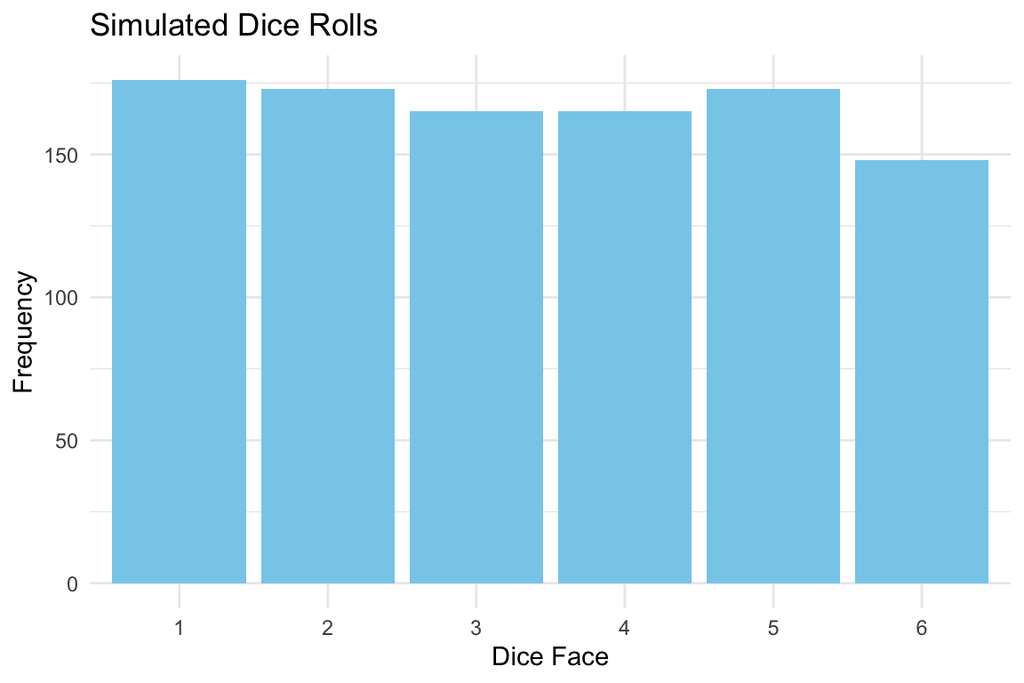

```r
set.seed(456)
dice_rolls <- sample(1:6, size = 1000, replace = TRUE)

# Frequency table
dice_df <- as.data.frame(table(dice_rolls))

# Bar plot
ggplot(dice_df, aes(x = dice_rolls, y = Freq)) +
  geom_bar(stat = "identity", fill = "skyblue") +
  labs(title = "Simulated Dice Rolls", x = "Dice Face", y = "Frequency") +
  theme_minimal()
```

Observation: Each face of the die appears with roughly equal frequency, consistent with a uniform distribution.

# 4 Exercise 3 - Simulating Normal Distribution

Generate 1000 samples from N(0, 1) and visualize the histogram.

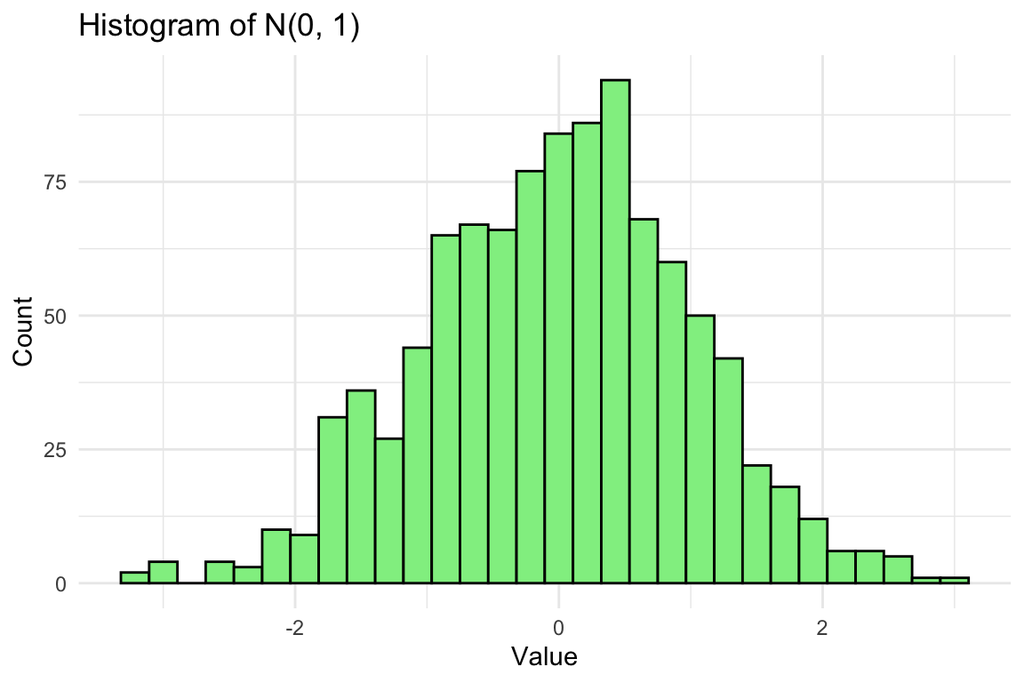

```r
set.seed(789)
norm_data <- rnorm(1000, mean = 0, sd = 1)

ggplot(data.frame(x = norm_data), aes(x = x)) +
  geom_histogram(bins = 30, fill = "lightgreen", color = "black") +
  labs(title = "Histogram of N(0, 1)", x = "Value", y = "Count") +
  theme_minimal()
```

Observation: The histogram forms a symmetric bell shape centered around zero, resembling a standard normal distribution.

# 5 Exercise 4 - Simulating Binomial Distribution

Simulate 1000 observations from Binomial(n=10, p=0.5).

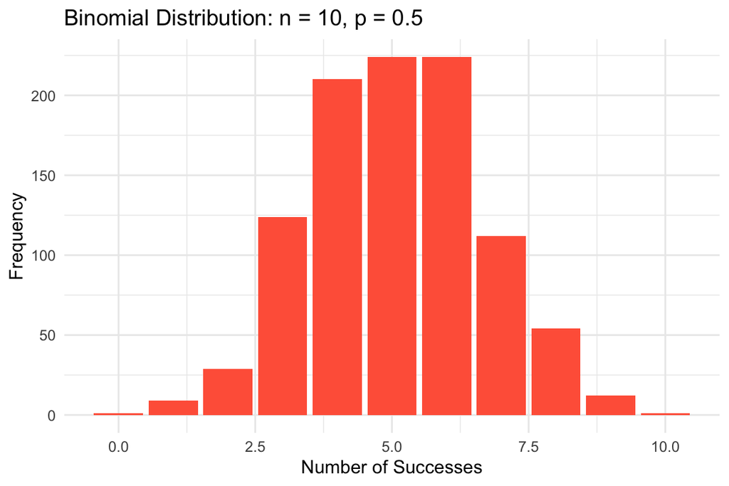

```r
set.seed(321)
binom_data <- rbinom(1000, size = 10, prob = 0.5)

ggplot(data.frame(x = binom_data), aes(x = x)) +
  geom_bar(fill = "tomato") +
  labs(title = "Binomial Distribution: n = 10, p = 0.5", x = "Number of Successes", y = "Frequency") +
  theme_minimal()
```

Observation: The distribution is symmetric and peaks at 5, aligning with the expected number of successes.

# 6 Exercise 5 - Simulating Poisson Distribution

Simulate 1000 samples from Poisson(λ=3).

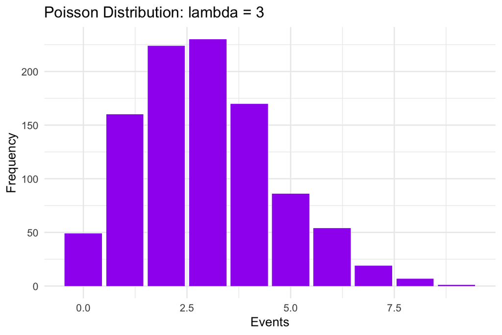

```r
set.seed(654)
pois_data <- rpois(1000, lambda = 3)

ggplot(data.frame(x = pois_data), aes(x = x)) +
  geom_bar(fill = "purple") +
  labs(title = "Poisson Distribution: lambda = 3", x = "Events", y = "Frequency") +
  theme_minimal()
```

Observation: The distribution is right-skewed with a peak around 2-3, characteristic of a Poisson process.

# 7 Exercise 6 - Law of Large Numbers (LLN) Visualization

Demonstrate convergence of sample mean to true mean using repeated sampling.

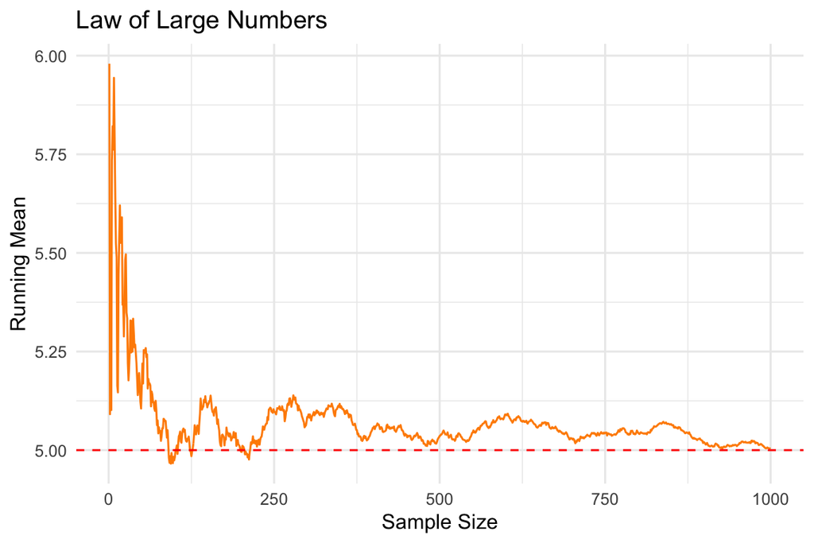

```r
set.seed(777)
samples <- rnorm(1000, mean = 5, sd = 2)
sample_means <- cumsum(samples) / (1:1000)

ggplot(data.frame(index = 1:1000, mean = sample_means), aes(x = index, y = mean)) +
  geom_line(color = "darkorange") +
  geom_hline(yintercept = 5, linetype = "dashed", color = "red") +
  labs(title = "Law of Large Numbers", x = "Sample Size", y = "Running Mean") +
  theme_minimal()
```

Observation: The running sample mean stabilizes near the true mean, demonstrating convergence as sample size increases.

# 8 Conclusion

This lab demonstrates how simulations in R can help visualize and understand key concepts in probability such as random events, distributions, and convergence. These simulations enhance our understanding of probability theory and lay the groundwork for further study in statistical inference and data modeling.